# Grafos

Prof. Dr. Henry Cagnini

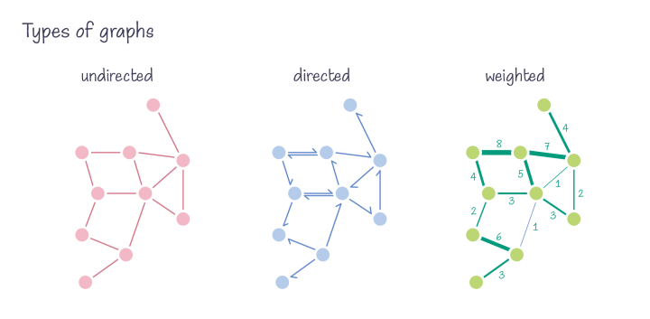

## Sumário

1. Introdução
   1. Conceitos e definições
2. Implementações em C
3. Árvores geradoras
   1. árvores geradoras mínimas
4. Algoritmo de Prim
5. Exemplo de aplicação
6. Bibliografia
7. Exercícios

## Introdução

### O que são grafos?

Um grafo é um tipo de estrutura de dados não-tabular, composta por entidades (nós ou vértices), em que os relacionamentos entre as entidades são demonstrados por arestas.

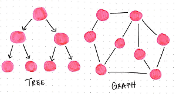

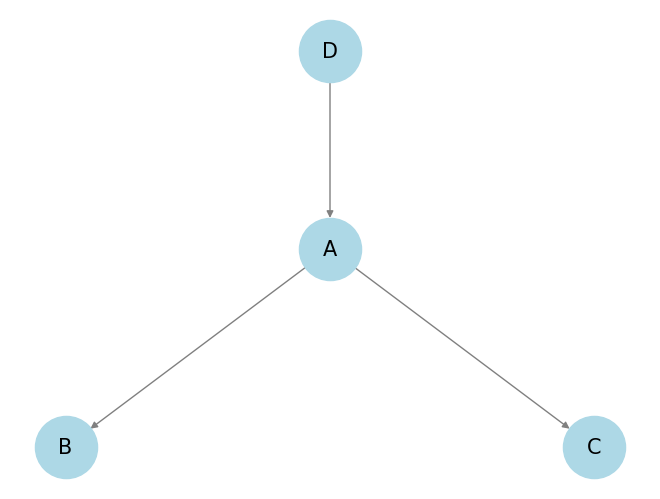

```python
draw_graph(
    graph_type=nx.DiGraph,
    edges=[('A', 'B', 0),  ('A', 'C', 0),  ('D', 'A', 0)]
)
```

## Tá... mas qual a diferença entre grafos e árvores?

Grafos possuem uma estrutura mais relaxada do que árvores:

🌲 Árvores possuem uma aridade, que é o número máximo de nós filhos que cada nó pode possuir. Esta restrição não se aplica a grafos

🚲 Grafos podem conter ciclos

➡️ Grafos podem ser direcionados ou não-direcionados, enquanto árvores são sempre direcionadas

### Direção em grafos

Existem dois tipos de grafos: direcionados e não-direcionados

Em um grafo direcionado, o sentido de movimento pode ser apenas na direção das setas. Esta restrição não existe em um grafo não-direcionado

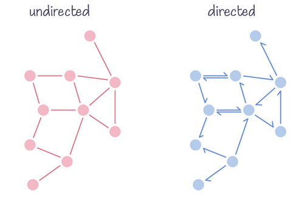

### Quais as características das arestas?

Geralmente, as arestas de um grafo possuem **pesos**. O peso é um valor que determina o custo de deslocamento de um nó à outro

Pensando em um exemplo de deslocamento entre cidades, o **peso** de uma aresta entre as cidades **Santa Maria** e **Cachoeira do Sul** seria a distância em kms destas cidades

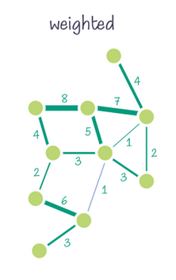

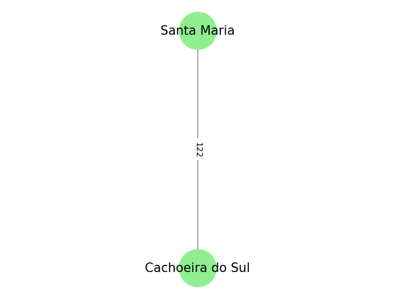

```python
draw_graph(
    graph_type=nx.Graph, edges=[('Santa Maria', 'Cachoeira do Sul', 122)],
    draw_weights=True,
    node_color='lightgreen'
)
```

## Representação em código-fonte

Existem duas maneiras de representar grafos em código-fonte: com **listas encadeadas** e com **matrizes de adjacência**.

Cada implementação possui seus prós e contras:

| Característica | Lista encadeada | Matriz de adjacências |
| --- | --- | --- |
| Complexidade de acesso | $O(n)$ | $O(1)$ |
| Complexidade de espaço | $O(n)$ | $O(n^2)$ |

### Lista encadeada

```python
mm(diagram_chained_list)
```

[figure not shown]

### Matriz de adjacências

|  | A | B | C | D |
| --- | --- | --- | --- | --- |
| **A** |  | 1 |  |  |
| **B** | 1 |  | 1 |  |
| **C** | 1 |  |  | 1 |
| **D** |  |  |  |  |

## Implementação como lista encadeada

Uma implementação em lista em C de grafos é a seguinte:

```
#include <stdio.h>
#include <stdlib.h>

struct Node {
    char *nome;
    int n_vizinhos;
    int *custos;
    struct Node* vizinhos;
};

struct Graph {
    int n_nos;
    struct Node* nos;
};
```

```
int main() {
    struct Graph *g = (struct Graph*)malloc(sizeof(struct Graph));
    g->n_nos = 3;

    g->nos = (struct Node*) malloc(sizeof(struct Node) * 3);
    g->nos[0].nome = "Santa Maria";
    g->nos[1].nome = "Cachoeira do Sul";
    g->nos[2].nome = "Frederico Westphalen";

    g->nos[0].n_vizinhos = 2;
    g->nos[1].n_vizinhos = 1;
    g->nos[2].n_vizinhos = 1;
```

```
g->nos[0].vizinhos = (struct Node*) malloc(sizeof(struct Node) * g->nos[0].n_vizinhos);
    g->nos[1].vizinhos = (struct Node*) malloc(sizeof(struct Node) * g->nos[1].n_vizinhos);
    g->nos[2].vizinhos = (struct Node*) malloc(sizeof(struct Node) * g->nos[2].n_vizinhos);

    g->nos[0].custos = (int*) malloc(sizeof(int) * g->nos[0].n_vizinhos);
    g->nos[1].custos = (int*) malloc(sizeof(int) * g->nos[1].n_vizinhos);
    g->nos[2].custos = (int*) malloc(sizeof(int) * g->nos[2].n_vizinhos);
```

```
g->nos[0].vizinhos[0] = g->nos[1];  // cachoeira do sul
    g->nos[0].vizinhos[1] = g->nos[2];  // frederico westphalen
    g->nos[1].vizinhos[0] = g->nos[0];  // santa maria
    g->nos[2].vizinhos[0] = g->nos[0];  // santa maria

    g->nos[0].custos[0] = 122;  // cachoeira do sul
    g->nos[0].custos[1] = 290;  // frederico westphalen
    g->nos[1].custos[0] = g->nos[0].custos[0];  // santa maria
    g->nos[2].custos[0] = g->nos[0].custos[1];  // santa maria
```

```
for(int i = 0; i < g->n_nos; i++) {
        printf(
            "O no %d se chama %s e possui %d vizinhos\n", i,
            g->nos[i].nome, g->nos[i].n_vizinhos
        );
        for(int j = 0; j < g->nos[i].n_vizinhos; j++) {
            printf(
                "\tO vizinho %d do no %s se chama %s e fica a %dkm\n", j,
                g->nos[i].nome, g->nos[i].vizinhos[j].nome, g->nos[i].custos[j]
            );
        }
    }

    return 0;
}
```

**Saída:**

```
O no 0 se chama Santa Maria e possui 2 vizinhos
    O vizinho 0 do no Santa Maria se chama Cachoeira do Sul e fica a 122km
    O vizinho 1 do no Santa Maria se chama Frederico Westphalen e fica a 290km
O no 1 se chama Cachoeira do Sul e possui 1 vizinhos
    O vizinho 0 do no Cachoeira do Sul se chama Santa Maria e fica a 122km
O no 2 se chama Frederico Westphalen e possui 1 vizinhos
    O vizinho 0 do no Frederico Westphalen se chama Santa Maria e fica a 290km
```

## Implementação como matriz de adjacências

```
#include <stdio.h>
#include <stdlib.h>

int main() {
    char **nomes = (char**)malloc(sizeof(char*) * 3);
    nomes[0] = "Santa Maria";
    nomes[1] = "Cachoeira do Sul";
    nomes[2] = "Frederico Westphalen";

    int n_nos = 3;

    int matrix[3][3];
```

```
matrix[0][0] = 0;
    matrix[0][1] = 122;
    matrix[0][2] = 290;
    matrix[1][0] = 122;
    matrix[1][1] = 0;
    matrix[1][2] = -1;  // sem conexão
    matrix[2][0] = 290;
    matrix[2][1] = -1;  // sem conexão
    matrix[2][2] = 0;
```

```
for(int i = 0; i < n_nos; i++) {
        printf("O no %d se chama %s\n", i, nomes[i]);
        int n_vizinhos = 0;
        for(int j = 0; j < n_nos; j++) {
            if(matrix[i][j] > 0) {
                printf(
                    "\tO vizinho %d do no %s se chama %s e fica a %dkm\n",
                    n_vizinhos, nomes[i], nomes[j], matrix[i][j]
                );
                n_vizinhos += 1;
            }
        }
    }
    return 0;
}
```

**Saída:**

```
O no 0 se chama Santa Maria
    O vizinho 0 do no Santa Maria se chama Cachoeira do Sul e fica a 122km
    O vizinho 1 do no Santa Maria se chama Frederico Westphalen e fica a 290km
O no 1 se chama Cachoeira do Sul
    O vizinho 0 do no Cachoeira do Sul se chama Santa Maria e fica a 122km
O no 2 se chama Frederico Westphalen
    O vizinho 0 do no Frederico Westphalen se chama Santa Maria e fica a 290km
```

## Árvores geradoras

Uma árvore geradora (*spanning tree* em inglês) é uma estrutura não-tabular, derivada de um grafo não-direcionado, sem ciclos, onde todos os vértices estão conectados uns aos outros por *algumas* de suas arestas.

## Árvores geradoras mínimas

Uma **árvore geradora mínima** (*Minimum Spanning Tree* ou MST em inglês) é uma estrutura não-tabular, derivada de um grafo não-direcionado, sem ciclos, onde todos os vértices estão conectados uns aos outros por *algumas* de suas arestas, **e** a soma do peso das arestas é a menor soma possível dentre todas as disponíveis.

### Aplicações de árvores geradoras mínimas

Uma aplicação de árvores geradoras mínimas está na tarefa de agrupamento da área de aprendizado de máquina.

Suponha que você possua um conjunto de dados com duas variáveis: a nota que um aluno tira em uma disciplina, e a porcentagem de presença do aluno na aula da disciplina. O conjunto de dados está distribuído no espaço cartesiano da seguinte forma:

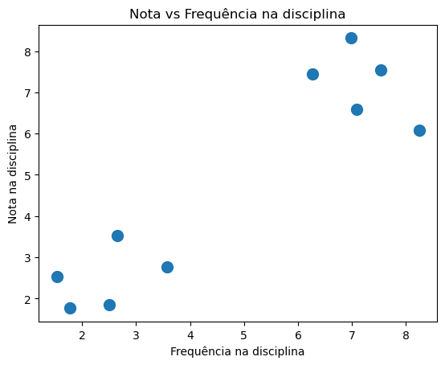

```python
fig, ax = plot_graph(X)
plt.show()
```

O objetivo da tarefa de agrupamento é colocar os pontos de dados (alunos) em grupos de maneira que cada ponto tenha mais características em comum com pontos do seu grupo do que pontos fora do seu grupo.

A qualidade dos arranjos (pontos em grupos) pode ser mensurada pela métrica da silhueta, que vai de -1 à 1: quanto maior o valor desta métrica, melhor.

Mas de que maneira arranjar os pontos em grupos?

Uma maneira de começar o problema é gerar uma **árvore geradora mínima** com os pontos de dados. Para cada ponto, conecta-se ele com seu vizinho mais próximo.

Existem diversos algoritmos para gerar uma árvore mínima geradora. Para este exemplo, usaremos o **Algoritmo de Prim:**

1. Escolha um vértice arbitrário para iniciar o processo
2. Siga os passos 3 a 5 até que não existam vértices a serem inclusos na MST
3. Encontre arestas que conectem os vértices da MST com os vértices de fora da MST
4. Dentre estes vértices, escolha o de menor peso
5. Adicione o vértice à MST, caso ele não gere um ciclo

```python
import numpy as np
import pandas as pd
from IPython.display import display

def distance(x1, x2):
    """Distância euclidiana"""
    return ((x1[0] - x2[0])**2 + (x1[1] - x2[1])**2)**(1./2.)

dists = np.array([[distance(x1, x2) for x2 in X] for x1 in X])
```

```python
display(pd.DataFrame(dists))
```

|  | 0 | 1 | 2 | 3 | 4 | 5 | 6 | 7 | 8 | 9 |
| --- | --- | --- | --- | --- | --- | --- | --- | --- | --- | --- |
| 0 | 0.000000 | 6.464275 | 5.336921 | 6.323870 | 1.486396 | 5.398506 | 1.668140 | 1.199442 | 6.153731 | 1.966032 |
| 1 | 6.464275 | 0.000000 | 1.129328 | 0.954054 | 7.942753 | 1.729729 | 7.861240 | 6.510092 | 2.556636 | 8.375174 |
| 2 | 5.336921 | 1.129328 | 0.000000 | 1.265190 | 6.817135 | 1.178916 | 6.735546 | 5.392514 | 2.386168 | 7.245901 |
| 3 | 6.323870 | 0.954054 | 1.265190 | 0.000000 | 7.809602 | 1.045790 | 7.588012 | 6.195441 | 1.610268 | 8.159406 |
| 4 | 1.486396 | 7.942753 | 6.817135 | 7.809602 | 0.000000 | 6.876980 | 1.181965 | 2.060992 | 7.589760 | 0.811563 |
| 5 | 5.398506 | 1.729729 | 1.178916 | 1.045790 | 6.876980 | 0.000000 | 6.591747 | 5.189788 | 1.254371 | 7.184548 |
| 6 | 1.668140 | 7.861240 | 6.735546 | 7.588012 | 1.181965 | 6.591747 | 0.000000 | 1.411416 | 7.131505 | 0.737129 |
| 7 | 1.199442 | 6.510092 | 5.392514 | 6.195441 | 2.060992 | 5.189788 | 1.411416 | 0.000000 | 5.723538 | 2.071580 |
| 8 | 6.153731 | 2.556636 | 2.386168 | 1.610268 | 7.589760 | 1.254371 | 7.131505 | 5.723538 | 0.000000 | 7.785235 |
| 9 | 1.966032 | 8.375174 | 7.245901 | 8.159406 | 0.811563 | 7.184548 | 0.737129 | 2.071580 | 7.785235 | 0.000000 |

```python
dists[np.where(dists == 0)] = np.inf
display(pd.DataFrame(dists))
```

|  | 0 | 1 | 2 | 3 | 4 | 5 | 6 | 7 | 8 | 9 |
| --- | --- | --- | --- | --- | --- | --- | --- | --- | --- | --- |
| 0 | inf | 6.464275 | 5.336921 | 6.323870 | 1.486396 | 5.398506 | 1.668140 | 1.199442 | 6.153731 | 1.966032 |
| 1 | 6.464275 | inf | 1.129328 | 0.954054 | 7.942753 | 1.729729 | 7.861240 | 6.510092 | 2.556636 | 8.375174 |
| 2 | 5.336921 | 1.129328 | inf | 1.265190 | 6.817135 | 1.178916 | 6.735546 | 5.392514 | 2.386168 | 7.245901 |
| 3 | 6.323870 | 0.954054 | 1.265190 | inf | 7.809602 | 1.045790 | 7.588012 | 6.195441 | 1.610268 | 8.159406 |
| 4 | 1.486396 | 7.942753 | 6.817135 | 7.809602 | inf | 6.876980 | 1.181965 | 2.060992 | 7.589760 | 0.811563 |
| 5 | 5.398506 | 1.729729 | 1.178916 | 1.045790 | 6.876980 | inf | 6.591747 | 5.189788 | 1.254371 | 7.184548 |
| 6 | 1.668140 | 7.861240 | 6.735546 | 7.588012 | 1.181965 | 6.591747 | inf | 1.411416 | 7.131505 | 0.737129 |
| 7 | 1.199442 | 6.510092 | 5.392514 | 6.195441 | 2.060992 | 5.189788 | 1.411416 | inf | 5.723538 | 2.071580 |
| 8 | 6.153731 | 2.556636 | 2.386168 | 1.610268 | 7.589760 | 1.254371 | 7.131505 | 5.723538 | inf | 7.785235 |
| 9 | 1.966032 | 8.375174 | 7.245901 | 8.159406 | 0.811563 | 7.184548 | 0.737129 | 2.071580 | 7.785235 | inf |

```python
def cheapest(dists, added, not_added):
    """Acha a aresta de menor peso"""
    cost = np.inf
    pivot = None
    cand = None
    for a in added:
        for n in not_added:
            if dists[a][n] <= cost:
                cost = dists[a][n]
                pivot = a
                cand = n

    return pivot, cand, cost
```

```python
def find_mst(dists, added, not_added):
    G = nx.Graph()

    while len(not_added) > 0:
        pivot, cand, cost = cheapest(dists, added, not_added)

        G.add_edge(pivot, cand, weight=cost)

        print(f'{cand}', end=' ')
        added  = added.union({cand})
        not_added -= {cand}

    return G
```

```python
added = set([0])   # {0}
not_added = {i for i in range(1, 10)}  # {1, 2, 3, ..., 9}
print('ordem de adição dos nós: 0', end=' ')
G = find_mst(dists, added, not_added)
```

```
ordem de adição dos nós: 0 7 6 9 4 5 3 1 2 8
```

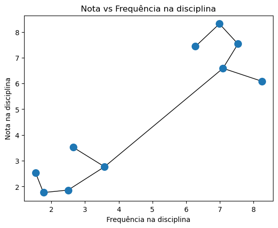

```python
fig, ax = plot_graph(X)
fig, ax = plot_edges(fig, ax, G, X)
plt.show()
```

## E agora?

Desenhamos a árvore geradora mínima. Mas e agora?

Para o problema de **agrupamento**, precisamos **remover** arestas, calcular a métrica da silhueta, e escolher o agrupamento gerado pela melhor configuração de remoções

No artigo *PASCAL: An EDA for Parameterless Shape-Independent Clustering*, foi utilizado um algortimo evolutivo para testar combinações de remoções possíveis

Nem todas as combinações foram testadas, dado que este problema é NP-difícil!

Para propósitos desta aula (e respeitando o escopo do assunto), nos limitaremos a remover apenas uma aresta por vez, diminuindo consideravelmente o espaço de busca:

```python
from sklearn.metrics import silhouette_score
import copy

scores = []
options = []
for a, b in G.edges():
    g = copy.deepcopy(G)
    g.remove_edge(a, b)
    group_a = nx.node_connected_component(g, a)
    group_b = nx.node_connected_component(g, b)
    labels = np.ones(10, dtype=int)
    labels[list(group_a)] = 0
    score = silhouette_score(X, labels)
    scores += [score]
    options += [(a, b)]

best = np.argmax(scores)
print(f'A aresta a ser removida gera uma silhueta de valor {scores[best]:.4f}')
```

```
A aresta a ser removida gera uma silhueta de valor 0.7790
```

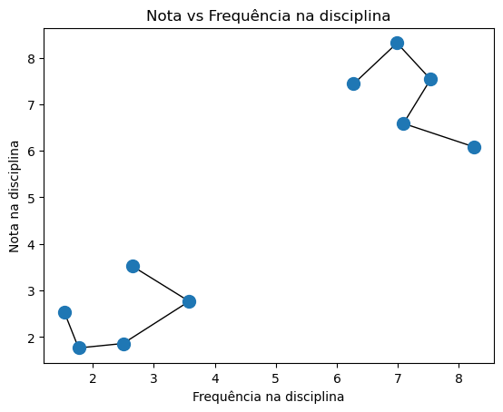

```python
fig, ax = plot_graph(X)
g = copy.deepcopy(G)
g.remove_edge(*options[best])
fig, ax = plot_edges(fig, ax, g, X)
plt.show()
```

## Conclusão

Esta é apenas uma aplicação de grafos!

Grafos estão em toda a parte: ao calcular rotas entre computadores em uma rede, fazer agrupamento de dados, verificar similaridade entre documentos, etc

Uma boa compreensão de grafos é essencial para a correta aplicação de seus algoritmos, e na resolução de problemas complexos!

## Exercícios

Você reparou em um problema no código-fonte do algoritmo de Prim em Python mostrado nesta aula?

Ele não tem um algoritmo de busca de ciclos no grafo!

Corrija o algoritmo de Prim, de maneira a incluir esta verificação.

Dica: procure na documentação da biblioteca `networkx` uma implementação pronta. Depois, confira o passo-a-passo com o seu algoritmo!

## Bibliografia

Cormen, Thomas H., et al. "Algoritmos: teoria e prática." Editora Campus 2 (2002): 296p.

Parte VI (capítulos 22 a 26)

[figure not shown]